# Augment JULES ensemble design

The purpose of this vignette is to augment an ensemble of JULES with new ensemble members, with input parameter configurations where we think the model output will fall within a set of constraints. The code writes a new set of configuration files.

```r
library(DiceKriging)
library(julesR)
library(emtools)
library(imptools)
library(viztools)
```

## Setup

Read data, set up some constants.

```r
years = 1861:2014
ysec = 60*60*24*365
# This is a "normalisation vector", for making the output numbers more manageable.
norm_vec = c(1e12, 1e12, 1e12/ysec , 1e12, 1e12, 1e9)

# Load up the data
# system.file find the specified file in package julesR
lhs_i = read.table(system.file('extdata/lhs_u-ao732.txt', package = 'julesR'), header = TRUE)
lhs_ii = read.table(system.file('extdata/lhs_u-ao732a.txt', package = 'julesR'), header = TRUE)

toplevel_ix = 1:499

lhs = rbind(lhs_i, lhs_ii)[toplevel_ix, ]

X = normalize(lhs)
colnames(X) = colnames(lhs)
d = ncol(X)


#dat <- read.csv(system.file('extdata/es_ppe_ii_annual_global_sum.csv', package = 'julesR'), header = TRUE)
dat <- read.csv(file = '~/myRpackages/julesR/inst/extdata/es_ppe_ii_annual_global_sum.csv', header = TRUE)

Y <- sweep(dat, 2, norm_vec, FUN = '/')
p <- ncol(Y)
```

## Level 0 constraint

The model is required to run, and have some sort of functioning carbon cycle. This sets runoff to greater than 0.5 Sv and nbp not too negative.

```r
allix = 1:(nrow(Y)) # this could be replaced with toplevel_ix above

# Constrain with global runoff and nbp, so that the emulator
# is not negatively affected by really bad points
level0_ix = which(Y[,'runoff'] >0.5 & Y[,'nbp'] > -10)
#
Y_level0  = Y[level0_ix, ]     # (scaled to sensible) data that passes level 0
X_level0 = X[level0_ix, ]               # Normalised inputs that pass level 0
lhs_level0 = lhs[level0_ix, ]           # Non-normalised inputs that pass level 0
#
nlevel0_ix = setdiff(allix, level0_ix)  # These inputs DO NOT PASS
X_nlevel0 = X[nlevel0_ix, ]
lhs_nlevel0 = lhs[nlevel0_ix, ]
#
# These are the ensemble members which do not run (produce NA)
na_ix = which(is.na(Y[,'runoff']))
X_na = X[na_ix, ]
lhs_na = lhs[na_ix, ]

dim(Y_level0)
```

```
#> [1] 393   6
```

There are 393 out of 499 members remaining that aren’t ruled out.

## Level 1 constraint

The model has a carbon cycle which is constrained to within broad ranges of a number of important outputs.

```r
# Apply level 1 constraints
level1_ix = which(Y[,'cs_gb'] > 750 & Y[,'cs_gb'] < 3000 &
  Y[,'cv'] > 300 & Y[,'cv'] < 800 &
  Y[,'npp_n_gb'] > 35 &
  Y[,'npp_n_gb'] < 80 &
  Y[,'runoff'] >0.5 &
  Y[,'nbp'] > -10
  )

X_level1 = X[level1_ix, ]

# Ranges of the inputs after a level 1 constraint
rn_l1 = apply(X_level1, 2, range)

nlevel1_ix = setdiff(allix, level1_ix)
X_nlevel1 = X[nlevel1_ix, ]

Y_level1 = Y[level1_ix, ]

dim(Y_level1)
```

```
#> [1] 53  6
```

Only 53 members remain with these.

## Setup history matching limits

```r
# In order to use the history matching code, we'll need to specify targets -
# specifically "observations" with uncertainty that approximately match our
# "hard boundaries" from the existing constraints.

# Initial guess just choose the centre of the (implied) uniform distribution.
#cs_gb.target = (3000 - 750) / 2
#cv.target = (800 - 300) / 2
#npp_n_gb.target = (80 - 35) / 2
#runoff.target = 1
#nbp.target = 0
#gpp.target = 75

#Y.target = c(cs_gb.target, cv.target, npp_n_gb.target, runoff.target, nbp.target)

# I'm going to set it so that +3sd aligns approximately with the original limits
# given by Andy Wiltshire.
#cs_gb       cv    gpp_gb        nbp npp_n_gb    runoff
Y_lower = c(750, 300, 50, -10, 35, 0.5)
Y_upper = c(3000, 800,200, 10, 80, 1.5)
Y_target = (Y_upper - abs(Y_lower)) / 2 # abs() to fix the problem with negative numbers


# standard deviation is derived from the limits and the central target
# (this distance is assumed to be 3 standard deviations.
Y_sd = (Y_upper - Y_target) / 3
names(Y_sd) = colnames(Y)

obs_sd_list = as.list(rep(0.01,p))
disc_list =  as.list(rep(0,p))
disc_sd_list =  as.list(Y_sd/2)
thres = 3

mins_aug = apply(X_level1, 2, FUN = min)
maxes_aug =apply(X_level1, 2, FUN = max)

# convert Y_target for ingestion into function
Y_target = matrix(Y_target, nrow = 1)
```

## Augment the design.

The function addNroyDesignPoints builds an emulator for each model output in Y. It compares the output of each emulator at a number of candidate desin points, and chooses a space-filling set of them that that are Not Ruled Out Yet (statistically close to the observation at Y_target).

```r
# Final output needs to be expressed in terms of original LHS, then put back out to conf files.

# This function adds n.aug potential design points, and finds their implausibility
# score in X.nroy

wave1 = addNroyDesignPoints(X = X_level1,
                            Y = Y_level1,
                            Y_target = Y_target,
                            n_aug = 10000,
                            mins_aug = mins_aug,
                            maxes_aug = maxes_aug,
                            thres = 3,
                            disc_list=disc_list,
                            disc_sd_list = disc_sd_list,
                            obs_sd_list = obs_sd_list,
                            n_app = 50,
                            nreps = 100)
```

```r
source('default_jules_parameter_perturbations.R')

# Easiest way to generate a design of the right size is to have a "fac" which takes
# the names from the parameter list, and then multiplies everything by 0.5 or 2

tf <- 'l_vg_soil'
# we don't want anything that is TRUE/FALSE to be in fac
fac.init <- names(paramlist)
not_tf.ix <- which(names(paramlist)!=tf)
paramlist.trunc <-paramlist[not_tf.ix]

fac <- names(paramlist.trunc)

maxfac <-lapply(paramlist.trunc,function(x) x$max[which.max(x$max)] / x$standard[which.max(x$max)])
minfac <- lapply(paramlist.trunc,function(x) x$min[which.max(x$max)] / x$standard[which.max(x$max)])
```

## Write the augmented design

The function write_jules_design here simply takes the points calculated by addNroyDesignPoints and writes them to configuration files.

```r
# create a directory for the configuration files
confdir <- 'conf_files_augment'

dir.create(confdir)

X_mm = wave1$X_mm

# This is the function that writes the configuration files.
write_jules_design(X_mm = X_mm, paramlist=paramlist, n = nrow(X_mm),
                    fac = fac, minfac = minfac, maxfac = maxfac,
                    tf = tf,
                    fnprefix = paste0(confdir,'/param-perturb-P'),
                    lhsfn = paste0(confdir,'/lhs_example.txt'),
                    stanfn = paste0(confdir,'/stanparms_example.txt'),
                    allstanfn = paste0(confdir,'/allstanparms_example.txt'),
                    rn = 12,
                    startnum = 100)
```

## Check the design

Check that the augmented design produces what we expect. New ensemble members should be somewhat constrained within the boundaries of the original design, if the comparison to data offers any constraint.

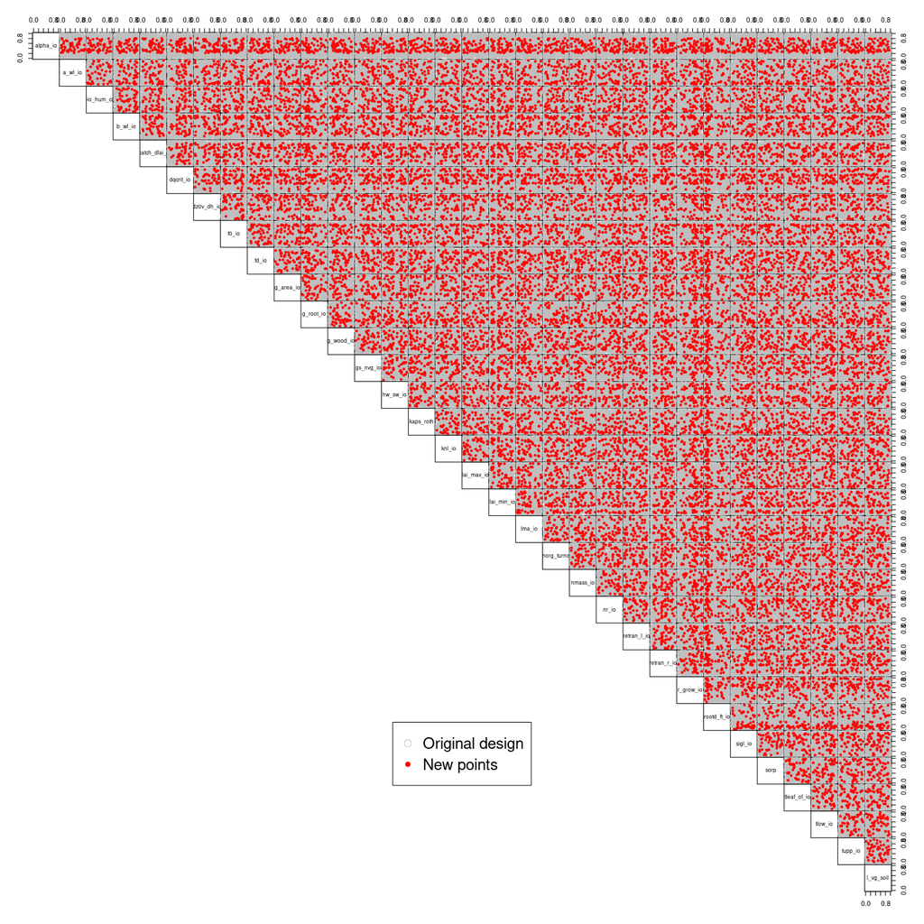

```r
pairs(rbind(X, X_mm), xlim = c(0,1), ylim = c(0,1), gap = 0, lower.panel = NULL,
      col = c(rep('grey', nrow(X)), rep('red', nrow(X_mm))),
      pch = c(rep(21, nrow(X)), rep(20, nrow(X_mm)))
      )

par(xpd = NA)

legend('bottom',
       legend = c('Original design', 'New points'),
       col = c('grey', 'red'),
       inset = 0.15,
       cex = 1.5,
       pch = c(21,20)
)
```